# Eighth Week: Text Analysis in R

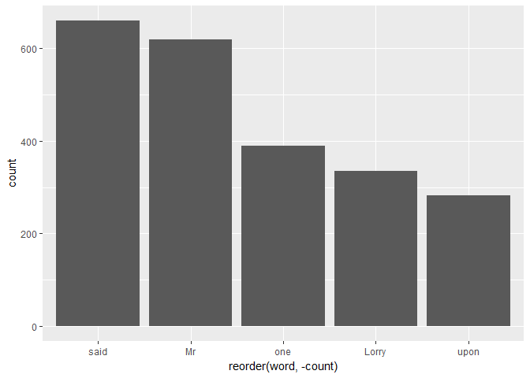

```r
  wstone = ATaleOfTwoCities %>%
    str_replace_all("\"","") %>%
    str_replace_all("[[:punct:]]","") %>%
    str_split(pattern = "\\s") %>%
    unlist() %>%
    table() %>%
    as.data.frame(stringsAsFactors = F)
  colnames(wstone) = c("word","count")


  wstone = wstone %>%
    filter(!str_to_lower(word) %in% stopwords('en')) %>%
    filter(str_length(word)>1) %>%
    filter(!str_detect(word,"\\d")) %>%
    arrange(desc(count)) %>%
    mutate(proper = !word %in% str_to_lower(word))



ggplot(data = wstone[1:5,], aes(reorder(word, -count), y = count)) + geom_bar(stat = 'identity',na.rm = TRUE)
```

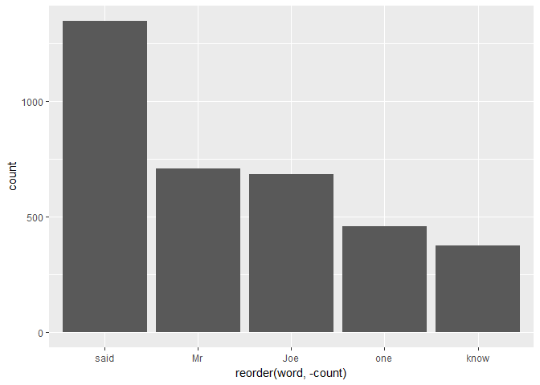

```r
  wstone = GreatExpectations %>%
    str_replace_all("\"","") %>%
    str_replace_all("[[:punct:]]","") %>%
    str_split(pattern = "\\s") %>%
    unlist() %>%
    table() %>%
    as.data.frame(stringsAsFactors = F)
  colnames(wstone) = c("word","count")


  wstone = wstone %>%
    filter(!str_to_lower(word) %in% stopwords('en')) %>%
    filter(str_length(word)>1) %>%
    filter(!str_detect(word,"\\d")) %>%
    arrange(desc(count)) %>%
    mutate(proper = !word %in% str_to_lower(word))



ggplot(data = wstone[1:5,], aes(reorder(word, -count), y = count)) + geom_bar(stat = 'identity',na.rm = TRUE)
```

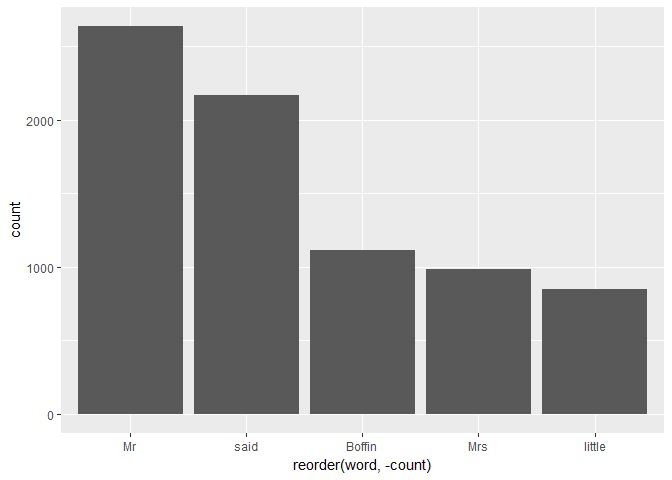

```r
  wstone = OurMutualFriend %>%
    str_replace_all("\"","") %>%
    str_replace_all("[[:punct:]]","") %>%
    str_split(pattern = "\\s") %>%
    unlist() %>%
    table() %>%
    as.data.frame(stringsAsFactors = F)
  colnames(wstone) = c("word","count")


  wstone = wstone %>%
    filter(!str_to_lower(word) %in% stopwords('en')) %>%
    filter(str_length(word)>1) %>%
    filter(!str_detect(word,"\\d")) %>%
    arrange(desc(count)) %>%
    mutate(proper = !word %in% str_to_lower(word))



ggplot(data = wstone[1:5,], aes(reorder(word, -count), y = count)) + geom_bar(stat = 'identity',na.rm = TRUE)
```

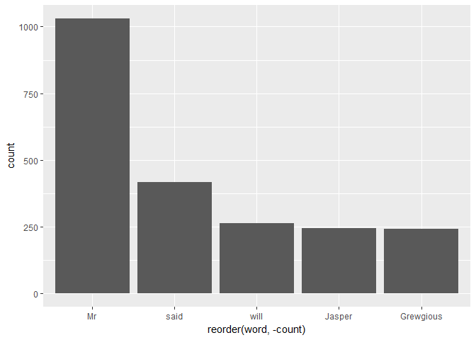

```r
  wstone = TheMysteryOfEdwinDrood %>%
    str_replace_all("\"","") %>%
    str_replace_all("[[:punct:]]","") %>%
    str_split(pattern = "\\s") %>%
    unlist() %>%
    table() %>%
    as.data.frame(stringsAsFactors = F)
  colnames(wstone) = c("word","count")


  wstone = wstone %>%
    filter(!str_to_lower(word) %in% stopwords('en')) %>%
    filter(str_length(word)>1) %>%
    filter(!str_detect(word,"\\d")) %>%
    arrange(desc(count)) %>%
    mutate(proper = !word %in% str_to_lower(word))



ggplot(data = wstone[1:5,], aes(reorder(word, -count), y = count)) + geom_bar(stat = 'identity',na.rm = TRUE)
```

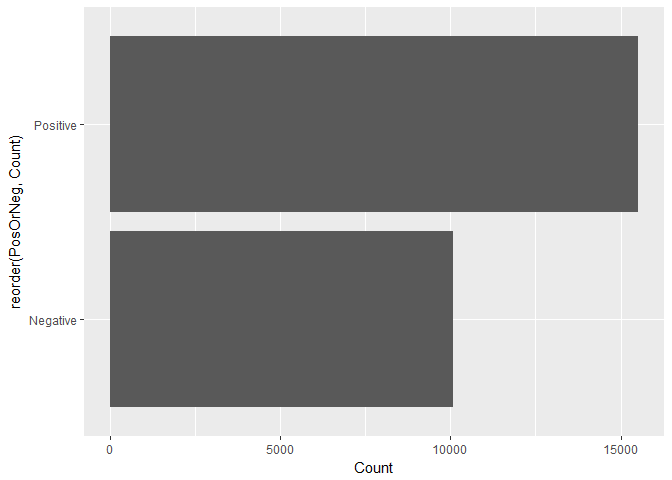

```r
colnames(OurMutualFriend1) = c("word","count")
sentiments %>% filter(lexicon == "nrc") %>% select(word, sentiment) %>%
  filter(word %in% OurMutualFriend1$word) %>%
  filter(sentiment == "negative" | sentiment == "positive") %>%
  select(word, sentiment) -> senti
  OurMutualFriend1 %>% filter(word %in% senti$word) -> words
  senti %>% filter(word %in% words$word) -> senti
  full_join(senti, words) -> words
  words %>% group_by(sentiment) %>% summarise(count = sum(count)) ->
    book_senti
  a = book_senti$count[which(book_senti$sentiment == "positive")]
  b = book_senti$count[which(book_senti$sentiment == "negative")]
  if(length(a) == 0)
    a = 0
  if(length(b) == 0)
    a = 0

   A = data.frame(
 Lab = c("Positive","Negative"),
 Val = c(a,b)
 )
 colnames(A) = c("PosOrNeg","Count")
 ggplot(data = A, aes(reorder(PosOrNeg, Count), y = Count)) + geom_bar(stat = 'identity',na.rm = TRUE) + coord_flip()
```

۵. متن داستان بینوایان را به ۲۰۰ قسمت مساوی تقسیم کنید. برای هر قسمت تعداد لغات positive و negative را حساب کنید و سپس این دو سری زمانی را در کنار هم برای مشاهده فضای احساسی داستان رسم نمایید.

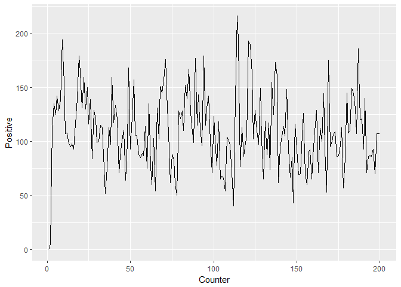

```r
txt = LesMiserable$text
k = ceiling(length(txt) / 200)
pos = NULL
neg = NULL
x = NULL
PN = list()
for (i in 1:199) {
  seg = txt[(1+(i-1)*k):(k+(i-1)*k)]

  wstone = seg %>% str_replace_all("\""," ") %>%
  str_replace_all("[:punct:]"," ") %>%
  str_split(pattern = "\\s") %>%
  unlist() %>%
  table %>%
  as.data.frame(strinfAsFactor = F)
colnames(wstone) = c("word","count")

  wstone = wstone %>%
    filter(!str_to_lower(word) %in% stop_words$word) %>%
    filter(!word %in% stop_words$word) %>%
    filter(!str_to_upper(word) %in% stop_words$word) %>%
    filter(str_length(word)>2) %>%
    filter(!str_detect(word,"\\d")) %>%
    arrange(desc(count))


  sentiments %>% filter(lexicon == "nrc") %>% select(word, sentiment) %>%
    filter(word %in% wstone$word) %>%
    filter(sentiment == "negative" | sentiment == "positive") %>%
    select(word, sentiment) -> senti
    wstone %>% filter(word %in% senti$word) -> words
    senti %>% filter(word %in% words$word) -> senti
     full_join(senti, words) -> words
    words %>% group_by(sentiment) %>% summarise(count = sum(count)) ->
      book_senti
    a = book_senti$count[which(book_senti$sentiment == "positive")]
    b = book_senti$count[which(book_senti$sentiment == "negative")]
    if(length(a) == 0)
      a = 0
    if(length(b) == 0)
      b = 0

    pos = c(pos,a)
    neg = c(neg,b)
    x = c(x,i)


}


fin = txt[(1+(200-1)*k):67273]

  wstone = fin %>% str_replace_all("\""," ") %>%
  str_replace_all("[:punct:]"," ") %>%
  str_split(pattern = "\\s") %>%
  unlist() %>%
  table %>%
  as.data.frame(strinfAsFactor = F)
colnames(wstone) = c("word","count")

  wstone = wstone %>%
    filter(!str_to_lower(word) %in% stop_words$word) %>%
    filter(!word %in% stop_words$word) %>%
    filter(!str_to_upper(word) %in% stop_words$word) %>%
    filter(str_length(word)>2) %>%
    filter(!str_detect(word,"\\d")) %>%
    arrange(desc(count))

  sentiments %>% filter(lexicon == "nrc") %>% select(word, sentiment) %>%
    filter(word %in% wstone$word) %>%
    filter(sentiment == "negative" | sentiment == "positive") %>%
    select(word, sentiment) -> senti
    wstone %>% filter(word %in% senti$word) -> words
    senti %>% filter(word %in% words$word) -> senti
     full_join(senti, words) -> words
    words %>% group_by(sentiment) %>% summarise(count = sum(count)) ->
      book_senti
    plist = book_senti$count[which(book_senti$sentiment == "positive")]
    nlist = book_senti$count[which(book_senti$sentiment == "negative")]
    if(length(plist) == 0)
      plist = 0
    if(length(nlist) == 0)
      nlist = 0
    pos = c(pos,a)
    neg = c(neg,b)
    x = c(x,200)
    PN = data.frame(pos,neg,x)
    colnames(PN) = c("Positive","Negative","Counter")

ggplot(data = PN, aes(x=Counter,y = Positive)) + geom_line(stat = 'identity',na.rm = TRUE)
```

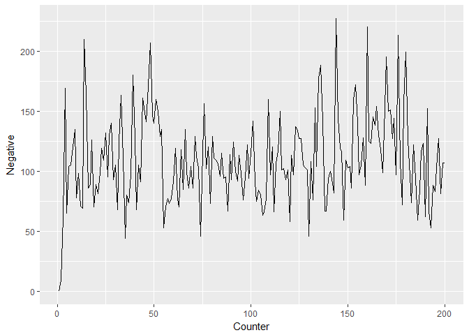

```r
ggplot(data = PN, aes(x=Counter,y = Negative)) +  geom_line(stat = 'identity',na.rm = TRUE)
```

۶. ابتدا ترکیبات دوتایی کلماتی که پشت سر هم می آیند را استخراج کنید و سپس نمودار ۳۰ جفت لغت پرتکرار را رسم نمایید.

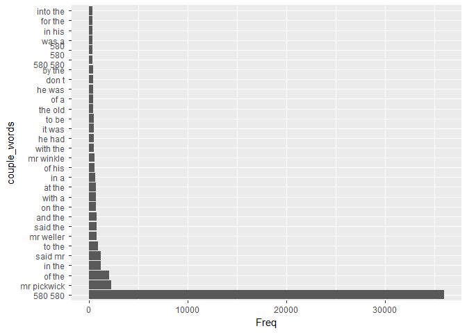

```r
  ThePickwickPapers %>%  str_replace_all("\"","") %>%
  str_replace_all("[[:punct:]]"," ") %>% sapply(tolower) %>% ngram(n = 2,sep = " ") ->x
  d = get.phrasetable(x)[1:2]
  colnames(d) = c("couple_words","freq")
  ggplot(data = d[1:30,],aes(x = reorder(couple_words, -freq), y = freq)) + geom_bar(stat = 'identity',na.rm = TRUE) + ylab("Freq") + xlab("couple_words") + coord_flip()
```

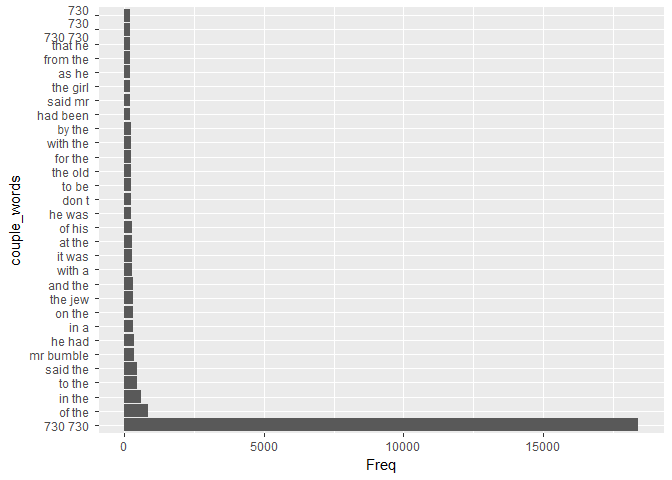

```r
  OliverTwist %>%  str_replace_all("\"","") %>%
  str_replace_all("[[:punct:]]"," ") %>% sapply(tolower) %>% ngram(n = 2,sep = " ") ->x
  d = get.phrasetable(x)[1:2]
  colnames(d) = c("couple_words","freq")
  ggplot(data = d[1:30,],aes(x = reorder(couple_words, -freq), y = freq)) + geom_bar(stat = 'identity',na.rm = TRUE) + ylab("Freq") + xlab("couple_words") + coord_flip()
```

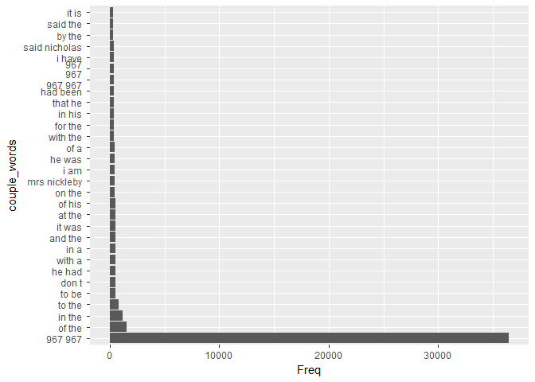

```r
  NicholasNickleby %>%  str_replace_all("\"","") %>%
  str_replace_all("[[:punct:]]"," ") %>% sapply(tolower) %>% ngram(n = 2,sep = " ") ->x
  d = get.phrasetable(x)[1:2]
  colnames(d) = c("couple_words","freq")
  ggplot(data = d[1:30,],aes(x = reorder(couple_words, -freq), y = freq)) + geom_bar(stat = 'identity',na.rm = TRUE) + ylab("Freq") + xlab("couple_words") + coord_flip()
```

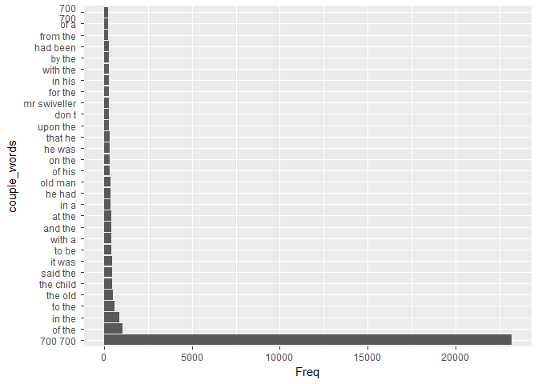

```r
  TheOldCurisityShop %>%  str_replace_all("\"","") %>%
  str_replace_all("[[:punct:]]"," ") %>% sapply(tolower) %>% ngram(n = 2,sep = " ") ->x
  d = get.phrasetable(x)[1:2]
  colnames(d) = c("couple_words","freq")
  ggplot(data = d[1:30,],aes(x = reorder(couple_words, -freq), y = freq)) + geom_bar(stat = 'identity',na.rm = TRUE) + ylab("Freq") + xlab("couple_words") + coord_flip()
```

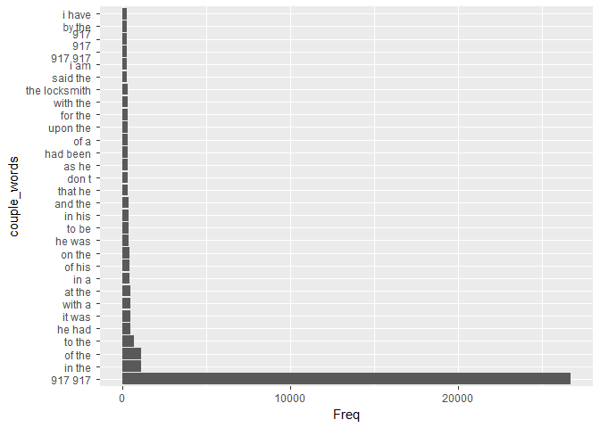

```r
  BarnabyRudge %>%  str_replace_all("\"","") %>%
  str_replace_all("[[:punct:]]"," ") %>% sapply(tolower) %>% ngram(n = 2,sep = " ") ->x
  d = get.phrasetable(x)[1:2]
  colnames(d) = c("couple_words","freq")
  ggplot(data = d[1:30,],aes(x = reorder(couple_words, -freq), y = freq)) + geom_bar(stat = 'identity',na.rm = TRUE) + ylab("Freq") + xlab("couple_words") + coord_flip()
```

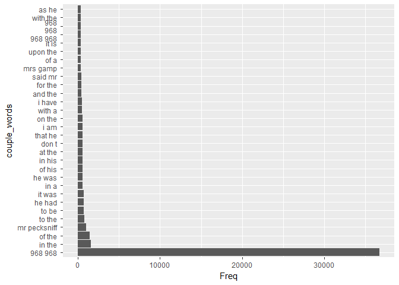

```r
  MartinChuzzlewit %>%  str_replace_all("\"","") %>%
  str_replace_all("[[:punct:]]"," ") %>% sapply(tolower) %>% ngram(n = 2,sep = " ") ->x
  d = get.phrasetable(x)[1:2]
  colnames(d) = c("couple_words","freq")
  ggplot(data = d[1:30,],aes(x = reorder(couple_words, -freq), y = freq)) + geom_bar(stat = 'identity',na.rm = TRUE) + ylab("Freq") + xlab("couple_words") + coord_flip()
```

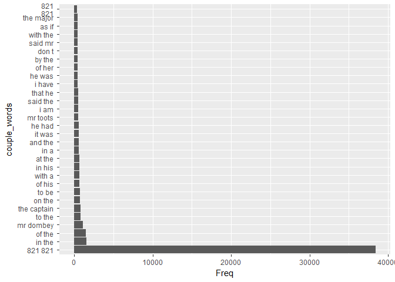

```r
  DombeyandSon %>%  str_replace_all("\"","") %>%
  str_replace_all("[[:punct:]]"," ") %>% sapply(tolower) %>% ngram(n = 2,sep = " ") ->x
  d = get.phrasetable(x)[1:2]
  colnames(d) = c("couple_words","freq")
  ggplot(data = d[1:30,],aes(x = reorder(couple_words, -freq), y = freq)) + geom_bar(stat = 'identity',na.rm = TRUE) + ylab("Freq") + xlab("couple_words") + coord_flip()
```

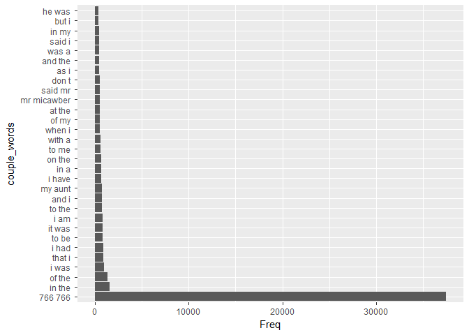

```r
  DavidCopperfield %>%  str_replace_all("\"","") %>%
  str_replace_all("[[:punct:]]"," ") %>% sapply(tolower) %>% ngram(n = 2,sep = " ") ->x
  d = get.phrasetable(x)[1:2]
  colnames(d) = c("couple_words","freq")
  ggplot(data = d[1:30,],aes(x = reorder(couple_words, -freq), y = freq)) + geom_bar(stat = 'identity',na.rm = TRUE) + ylab("Freq") + xlab("couple_words") + coord_flip()
```

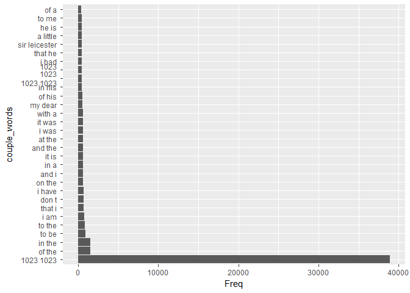

```r
  BleakHouse %>%  str_replace_all("\"","") %>%
  str_replace_all("[[:punct:]]"," ") %>% sapply(tolower) %>% ngram(n = 2,sep = " ") ->x
  d = get.phrasetable(x)[1:2]
  colnames(d) = c("couple_words","freq")
  ggplot(data = d[1:30,],aes(x = reorder(couple_words, -freq), y = freq)) + geom_bar(stat = 'identity',na.rm = TRUE) + ylab("Freq") + xlab("couple_words") + coord_flip()
```

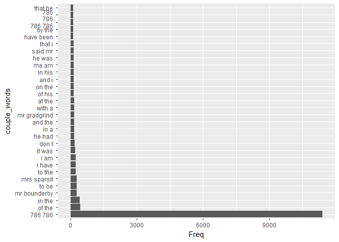

```r
  HardTimes %>%  str_replace_all("\"","") %>%
  str_replace_all("[[:punct:]]"," ") %>% sapply(tolower) %>% ngram(n = 2,sep = " ") ->x
  d = get.phrasetable(x)[1:2]
  colnames(d) = c("couple_words","freq")
  ggplot(data = d[1:30,],aes(x = reorder(couple_words, -freq), y = freq)) + geom_bar(stat = 'identity',na.rm = TRUE) + ylab("Freq") + xlab("couple_words") + coord_flip()
```

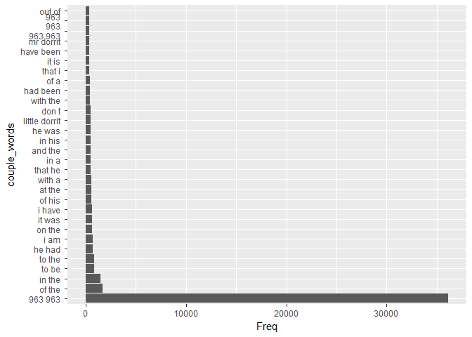

```r
  LittleDorrit %>%  str_replace_all("\"","") %>%
  str_replace_all("[[:punct:]]"," ") %>% sapply(tolower) %>% ngram(n = 2,sep = " ") ->x
  d = get.phrasetable(x)[1:2]
  colnames(d) = c("couple_words","freq")
  ggplot(data = d[1:30,],aes(x = reorder(couple_words, -freq), y = freq)) + geom_bar(stat = 'identity',na.rm = TRUE) + ylab("Freq") + xlab("couple_words") + coord_flip()
```

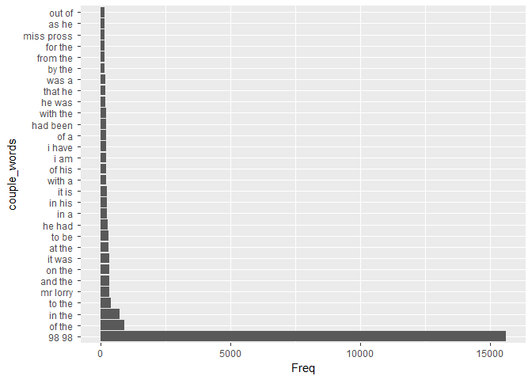

```r
  ATaleOfTwoCities %>%  str_replace_all("\"","") %>%
  str_replace_all("[[:punct:]]"," ") %>% sapply(tolower) %>% ngram(n = 2,sep = " ") ->x
  d = get.phrasetable(x)[1:2]
  colnames(d) = c("couple_words","freq")
  ggplot(data = d[1:30,],aes(x = reorder(couple_words, -freq), y = freq)) + geom_bar(stat = 'identity',na.rm = TRUE) + ylab("Freq") + xlab("couple_words") + coord_flip()
```

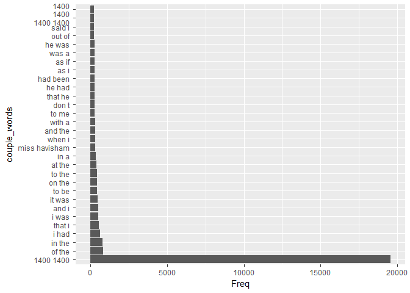

```r
  GreatExpectations %>%  str_replace_all("\"","") %>%
  str_replace_all("[[:punct:]]"," ") %>% sapply(tolower) %>% ngram(n = 2,sep = " ") ->x
  d = get.phrasetable(x)[1:2]
  colnames(d) = c("couple_words","freq")
  ggplot(data = d[1:30,],aes(x = reorder(couple_words, -freq), y = freq)) + geom_bar(stat = 'identity',na.rm = TRUE) + ylab("Freq") + xlab("couple_words") + coord_flip()
```

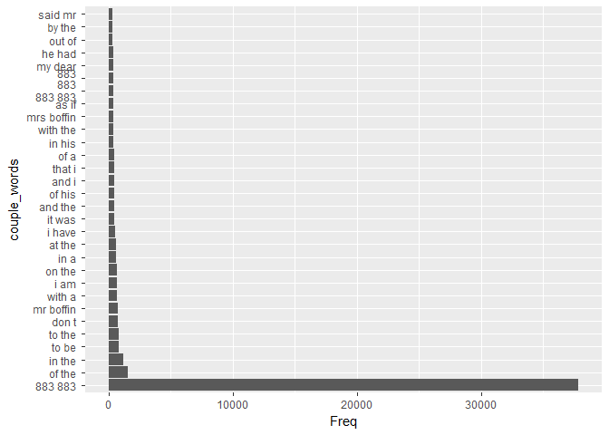

```r
  OurMutualFriend %>%  str_replace_all("\"","") %>%
  str_replace_all("[[:punct:]]"," ") %>% sapply(tolower) %>% ngram(n = 2,sep = " ") ->x
  d = get.phrasetable(x)[1:2]
  colnames(d) = c("couple_words","freq")
  ggplot(data = d[1:30,],aes(x = reorder(couple_words, -freq), y = freq)) + geom_bar(stat = 'identity',na.rm = TRUE) + ylab("Freq") + xlab("couple_words") + coord_flip()
```

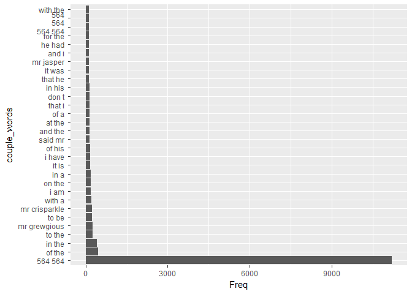

```r
  TheMysteryOfEdwinDrood %>%  str_replace_all("\"","") %>%
  str_replace_all("[[:punct:]]"," ") %>% sapply(tolower) %>% ngram(n = 2,sep = " ") ->x
  d = get.phrasetable(x)[1:2]
  colnames(d) = c("couple_words","freq")
  ggplot(data = d[1:30,],aes(x = reorder(couple_words, -freq), y = freq)) + geom_bar(stat = 'identity',na.rm = TRUE) + ylab("Freq") + xlab("couple_words") + coord_flip()
```

۷. جفت کلماتی که با she و یا he آغاز می شوند را استخراج کنید. بیست فعل پرتکراری که زنان و مردان در داستان های دیکنز انجام می دهند را استخراج کنید و نمودار آن را رسم نمایید.